# Project Python Foundations: FoodHub Data Analysis

By Abebaw Masresha June 2024

### Context

The number of restaurants in New York is increasing day by day. Lots of students and busy professionals rely on those restaurants due to their hectic lifestyles. Online food delivery service is a great option for them. It provides them with good food from their favorite restaurants. A food aggregator company FoodHub offers access to multiple restaurants through a single smartphone app.

The app allows the restaurants to receive a direct online order from a customer. The app assigns a delivery person from the company to pick up the order after it is confirmed by the restaurant. The delivery person then uses the map to reach the restaurant and waits for the food package. Once the food package is handed over to the delivery person, he/she confirms the pick-up in the app and travels to the customer's location to deliver the food. The delivery person confirms the drop-off in the app after delivering the food package to the customer. The customer can rate the order in the app. The food aggregator earns money by collecting a fixed margin of the delivery order from the restaurants.

### Objective

The food aggregator company has stored the data of the different orders made by the registered customers in their online portal. They want to analyze the data to get a fair idea about the demand of different restaurants which will help them in enhancing their customer experience. Suppose you are hired as a Data Scientist in this company and the Data Science team has shared some of the key questions that need to be answered. Perform the data analysis to find answers to these questions that will help the company to improve the business.

### Data Description

The data contains the different data related to a food order. The detailed data dictionary is given below.

### Data Dictionary

- order_id: Unique ID of the order
- customer_id: ID of the customer who ordered the food
- restaurant_name: Name of the restaurant
- cuisine_type: Cuisine ordered by the customer
- cost_of_the_order: Cost of the order
- day_of_the_week: Indicates whether the order is placed on a weekday or weekend (The weekday is from Monday to Friday and the weekend is Saturday and Sunday)
- rating: Rating given by the customer out of 5
- food_preparation_time: Time (in minutes) taken by the restaurant to prepare the food. This is calculated by taking the difference between the timestamps of the restaurant's order confirmation and the delivery person's pick-up confirmation.
- delivery_time: Time (in minutes) taken by the delivery person to deliver the food package. This is calculated by taking the difference between the timestamps of the delivery person's pick-up confirmation and drop-off information

### Let us start by importing the required libraries

```python
# Installing the libraries with the specified version.
# !pip install numpy==1.25.2 pandas==1.5.3 matplotlib==3.7.1 seaborn==0.13.1 -q --user
```

**Note**: *After running the above cell, kindly restart the notebook kernel and run all cells sequentially from the start again.*

```python
# import libraries for data manipulation
import numpy as np
import pandas as pd

# import libraries for data visualization
import matplotlib.pyplot as plt
import seaborn as sns
```

### Understanding the structure of the data

```python
# uncomment and run the following lines for Google Colab
from google.colab import drive
drive.mount('/content/drive');
```

```python
#path to the data
path="/content/drive/My Drive/AIML/foodhub_order.csv"

#read the data as csv
df=pd.read_csv(path)
```

```python
#get first five records
df.head(5)
```

|  | order_id | customer_id | restaurant_name | cuisine_type | cost_of_the_order | day_of_the_week | rating | food_preparation_time | delivery_time |
| --- | --- | --- | --- | --- | --- | --- | --- | --- | --- |
| 0 | 1477147 | 337525 | Hangawi | Korean | 30.75 | Weekend | Not given | 25 | 20 |
| 1 | 1477685 | 358141 | Blue Ribbon Sushi Izakaya | Japanese | 12.08 | Weekend | Not given | 25 | 23 |
| 2 | 1477070 | 66393 | Cafe Habana | Mexican | 12.23 | Weekday | 5 | 23 | 28 |
| 3 | 1477334 | 106968 | Blue Ribbon Fried Chicken | American | 29.20 | Weekend | 3 | 25 | 15 |
| 4 | 1478249 | 76942 | Dirty Bird to Go | American | 11.59 | Weekday | 4 | 25 | 24 |

### **Question 1:** How many rows and columns are present in the data? [0.5 mark]

```python
#get row and columns count
row_count, columns_count = df.shape

print(f" - There are {row_count} rows, and {columns_count} columns.")
```

```
 - There are 1898 rows, and 9 columns.
```

#### Observations:

### **Question 2:** What are the datatypes of the different columns in the dataset? (The info() function can be used) [0.5 mark]

```python
#get data types
df.info()
```

```
<class 'pandas.core.frame.DataFrame'>
RangeIndex: 1898 entries, 0 to 1897
Data columns (total 9 columns):
 #   Column                 Non-Null Count  Dtype
---  ------                 --------------  -----
 0   order_id               1898 non-null   int64
 1   customer_id            1898 non-null   int64
 2   restaurant_name        1898 non-null   object
 3   cuisine_type           1898 non-null   object
 4   cost_of_the_order      1898 non-null   float64
 5   day_of_the_week        1898 non-null   object
 6   rating                 1898 non-null   object
 7   food_preparation_time  1898 non-null   int64
 8   delivery_time          1898 non-null   int64
dtypes: float64(1), int64(4), object(4)
memory usage: 133.6+ KB
```

## Data Types:

1. 1 float64 data type column:
   - cost_of_the_order
2. 4 int64 data types columns/variables:
   - order_id
   - customer_id
   - food_preparation_time
   - delivery_time
3. 4 Object (String) data types:
   - restaurant_name
   - cuisine_type
   - day_of the week
   - rating

#### Observations:

### **Question 3:** Are there any missing values in the data? If yes, treat them using an appropriate method. [1 mark]

**Yes**, there are missing values in the data. I identified ratings labeled "Not given" as missing values in the following code block.

```python
# checking missing values
not_given_rating_count = len(df[df['rating'].str.lower()=='not given']['rating'])

print(f" - There are {not_given_rating_count} missing (Not givem) values in rating variable")

#get total rows for the df
total_rows_count=df.shape[0]

#check the percentage of "not given" rating
percent_of_not_given=int(not_given_rating_count*100/total_rows_count)

print(f" - About {percent_of_not_given} percent of the rating data is missing (Not given).")
```

```
 - There are 736 missing (Not givem) values in rating variable
 - About 38 percent of the rating data is missing (Not given).
```

**Treatment of "Not given" Ratings** - remove the missing values

We will handle the 'rating' column as follows:

- Remove the rows that do not have a rating (Not given).
- Convert the 'rating' column to integer type.

```python
# Copy the DataFrame to preserve the original data
rating_df = df.copy()

# Filter rows where the rating is not 'Not given'
rating_cleaned_df = rating_df[rating_df['rating'] != 'Not given'].copy()

# Convert 'rating' column to integers using .loc to avoid SettingWithCopyWarning
rating_cleaned_df.loc[:, 'rating'] = rating_cleaned_df['rating'].astype(int)

# View top 5 records
print(rating_cleaned_df.head(1).T)
```

```
                                 2
order_id                   1477070
customer_id                  66393
restaurant_name        Cafe Habana
cuisine_type               Mexican
cost_of_the_order            12.23
day_of_the_week            Weekday
rating                           5
food_preparation_time           23
delivery_time                   28
```

#### Observations:

### **Question 4:** Check the statistical summary of the data. What is the minimum, average, and maximum time it takes for food to be prepared once an order is placed? [2 marks]

```python
#stats of food_preparation_time
df['food_preparation_time'].describe().T
```

```
count    1898.000000
mean       27.371970
std         4.632481
min        20.000000
25%        23.000000
50%        27.000000
75%        31.000000
max        35.000000
Name: food_preparation_time, dtype: float64
```

#### Observations:

### **Question 5:** How many orders are not rated? [1 mark]

```python
# get orders that are not rated
unrated_count = df[df['rating'].str.lower()=='not given'].shape[0]

# get total orders
total_orders_count=df.shape[0]

print(f" - Out of the {total_orders_count}, {unrated_count} orders are not rated.")
print(f" - {int(unrated_count*100/total_orders_count)}% of the orders are not rated.")
```

```
 - Out of the 1898, 736 orders are not rated.
 - 38% of the orders are not rated.
```

#### Observations:

### Exploratory Data Analysis (EDA)

### **Question 6:** Explore all the variables and provide observations on their distributions. (Generally, histograms, boxplots, countplots, etc. are used for univariate exploration.) [9 marks]

# Order ID

**Check unique order_id**

```python
#check if order_id is unique
order_id_count = len(df['order_id'].unique())
if order_id_count==df.shape[0]:
    print(" - All order IDs are unique. There are no duplicate order IDs.")
else:
    print(" - There are duplicate order IDs.")
```

```
 - All order IDs are unique. There are no duplicate order IDs.
```

- All order IDs are unique. There are no duplicate order IDs.

# Customer ID

**One-time (unique) and repeating customers**

```python
#get the total number of unique customers
df_unique_customers=df['customer_id'].unique()

#get repeating customers
repeating_customers = df['customer_id'].duplicated().sum()

print(f" - There are {df_unique_customers.shape[0]} unique customers")
print(f" - There are {repeating_customers} repeating customers")
```

```
 - There are 1200 unique customers
 - There are 698 repeating customers
```

**Visualize the customer distrubution**

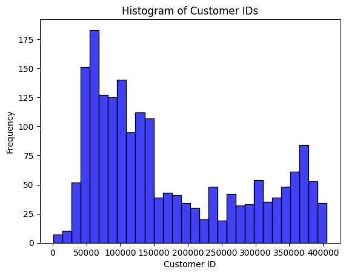

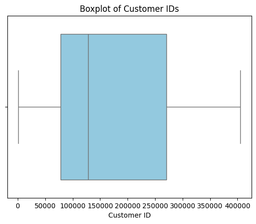

```python
# Plot histogram to visualize the distribution of customer_id in the orders
sns.histplot(data=df, x='customer_id', bins=30, kde=False, color='blue', edgecolor='black')
plt.title('Histogram of Customer IDs')
plt.xlabel('Customer ID')
plt.ylabel('Frequency')
plt.show()

# Add space between the histogram and the boxplot
print("\n" * 2)

# Plot boxplot to check for outliers in customer_id
sns.boxplot(data=df, x='customer_id', color='skyblue')
plt.title('Boxplot of Customer IDs')
plt.xlabel('Customer ID')
plt.show()
```

1. Customer ID distribution is right skewed. This implies that a large number of orders are being placed by a relatively small group of customers, indicating the presence of repeating customers.
2. There are no significant outliers in the customer ID data.

# Restaurant Name

**Unique restaurant counts**

```python
len(df['restaurant_name'].unique())

print(f" - There are {len(df['restaurant_name'].unique())} unique restaurants")
```

```
 - There are 178 unique restaurants
```

**Frequency / popularity of restaurant name**

```
                 restaurant_name  frequency
0                    Shake Shack        219
1              The Meatball Shop        132
2              Blue Ribbon Sushi        119
3      Blue Ribbon Fried Chicken         96
4                           Parm         68
5               RedFarm Broadway         59
6                 RedFarm Hudson         55
7                            TAO         49
8                    Han Dynasty         46
9  Blue Ribbon Sushi Bar & Grill         44

----------------------------
```

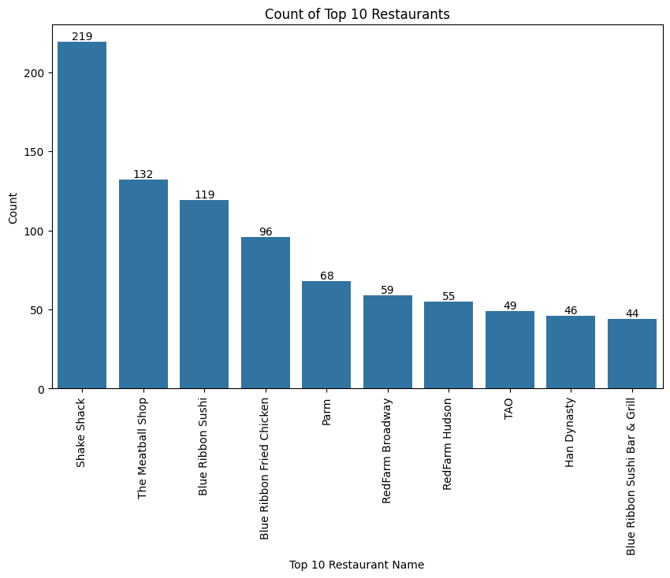

```python
# Group by 'restaurant_name' and count the number of occurrences
restaurant_frequency = df['restaurant_name'].value_counts().reset_index()

# Rename the columns for clarity
restaurant_frequency.columns = ['restaurant_name', 'frequency']

# top 10 restaurants by frequency
top_10_restaurants = restaurant_frequency.head(10)
print(top_10_restaurants)

#add a new line
print("\n----------------------------\n")

# Countplot for the top 10 'restaurant_name'
plt.figure(figsize=(10, 6))
ax= sns.countplot(data=df, x='restaurant_name', order=top_10_restaurants['restaurant_name'].value_counts().index)
plt.title('Count of Top 10 Restaurants')
plt.ylabel('Count')
plt.xlabel('Top 10 Restaurant Name')

# Add text labels above each bar
for p in ax.patches:
    ax.annotate(f'{int(p.get_height())}', (p.get_x() + p.get_width() / 2., p.get_height()),
                ha='center', va='center', fontsize=10, color='black', xytext=(0, 5),
                textcoords='offset points')

plt.xticks(rotation=90)  # Rotate x-axis labels for better readability
plt.show()
```

- **Shake Shack:** With 219 visits, it stands out as the most frequented restaurant in the dataset, indicating its popularity among customers.

# Cuisine Type

**Unique cuisine type**

```python
#get and print unique cusine types
print(f" - There are {len(df['cuisine_type'].unique())} unique cuisine types")
```

```
 - There are 14 unique cuisine types
```

**Frequency / Popularity of cusine type**

```python
# get unique cuisine types for each restaurant
unique_cuisine_types = df.groupby('restaurant_name')['cuisine_type'].unique()

# Create a DataFrame from the resulting Series
unique_cuisine_types_df = unique_cuisine_types.reset_index()

# Calculate the number of unique cuisine types for each restaurant
unique_cuisine_types_df['cuisine_count'] = unique_cuisine_types_df['cuisine_type'].apply(len)

# Sort the DataFrame by the number of unique cuisine types in descending order
sorted_cuisine_types_df = unique_cuisine_types_df.sort_values(by='cuisine_count', ascending=False)

# Get the top ten restaurants
top_ten_restaurants = sorted_cuisine_types_df.head(10)

# show the result
print(top_ten_restaurants)
```

```
               restaurant_name         cuisine_type  cuisine_count
153          The Meatball Shop  [Italian, American]              2
0                   'wichcraft           [American]              1
112           Pepe Rosso To Go            [Italian]              1
114             Piccolo Angolo            [Italian]              1
115  Pinto Nouveau Thai Bistro               [Thai]              1
116               Pongsri Thai               [Thai]              1
117                      Posto            [Italian]              1
118        Prosperity Dumpling            [Chinese]              1
119                      Pylos      [Mediterranean]              1
120       Ravagh Persian Grill     [Middle Eastern]              1
```

- 'The Meatball Shop' sold the following 2 cuisine types:
  - Italian
  - American'
- All other resturants sold only one cuisine type

```
      cuisine_type  count
0         American    584
5         Japanese    470
4          Italian    298
1          Chinese    215
8          Mexican     77
3           Indian     73
9   Middle Eastern     49
7    Mediterranean     46
12            Thai     19
2           French     18
10        Southern     17
6           Korean     13
11         Spanish     12
13      Vietnamese      7
```

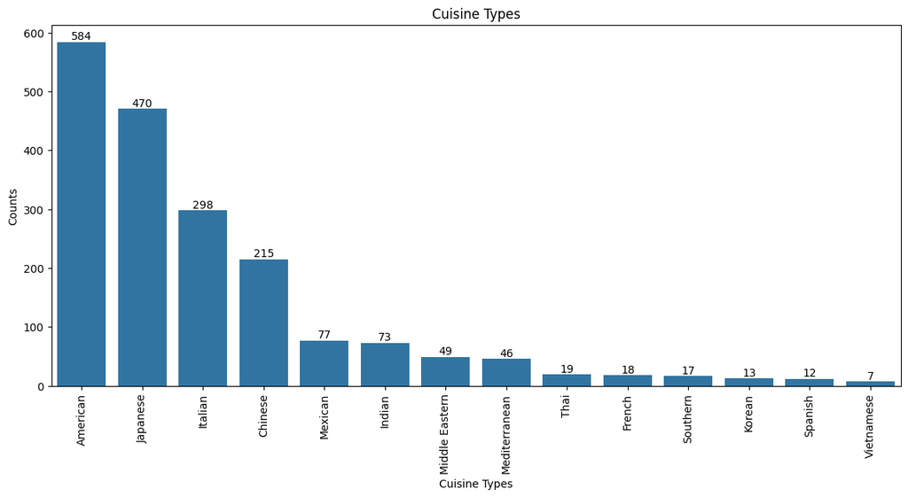

```python
#count cuisine types
df_cuisine_type_count= df.groupby('cuisine_type')['cuisine_type'].value_counts()

#reset the index
df_cuisine_type_count=df_cuisine_type_count.reset_index()

#sort in descending order
df_cuisine_type_count=df_cuisine_type_count.sort_values(by='count',ascending=False)
print(df_cuisine_type_count)

#add a new line
print()

# Countplot for the top 10 'restaurant_name'
plt.figure(figsize=(14, 6))
ax=sns.barplot(data=df_cuisine_type_count, x='cuisine_type', y='count')
plt.title('Cuisine Types')
plt.xlabel('Cuisine Types')
plt.ylabel('Counts')

# Add text labels above each bar
for p in ax.patches:
    ax.annotate(f'{int(p.get_height())}', (p.get_x() + p.get_width() / 2., p.get_height()),
                ha='center', va='center', fontsize=10, color='black', xytext=(0, 5),
                textcoords='offset points')

plt.xticks(rotation=90)  # Rotate x-axis labels for better readability
plt.show()
```

- American cuisine is the most popular with 584 orders.
- Japanese cuisine is the second most popular with 470 orders.
- Vietnamese cusine is the least popular with 7 orders.

# Cost of the order

```python
# descriptive stats on cost of the order
print (df['cost_of_the_order'].describe().T)

#add a new line
print("\n----------------------------\n")

# Find the top 10 most common costs of orders and their counts
top_10_costs = df['cost_of_the_order'].value_counts().head(10)

print("Top 10 costs of the order and the number of orders (customers) paid that amount:")
print(top_10_costs)
```

```
count    1898.000000
mean       16.498851
std         7.483812
min         4.470000
25%        12.080000
50%        14.140000
75%        22.297500
max        35.410000
Name: cost_of_the_order, dtype: float64

----------------------------

Top 10 costs of the order and the number of orders (customers) paid that amount:
cost_of_the_order
12.18    86
12.13    82
12.23    47
24.20    42
29.10    37
24.25    36
12.08    36
24.30    35
14.07    32
29.15    30
Name: count, dtype: int64
```

**Data Insight:**

- The average order costs 16.50 USD
- Range of orders cost is 4.47 to 35.41 USD
- Most orders fall between 12.08 and 22.30 USD
- Order costs of 12.18 and 12.13 USD are the most common, with 86 and 82 orders respectively."

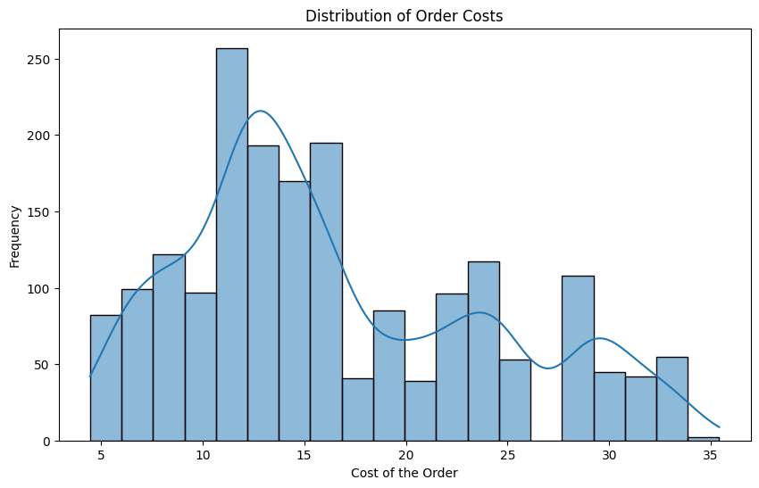

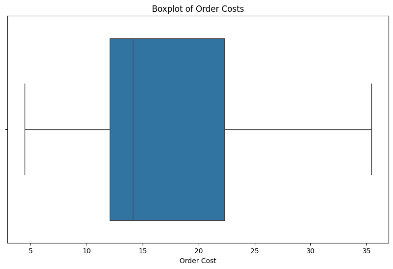

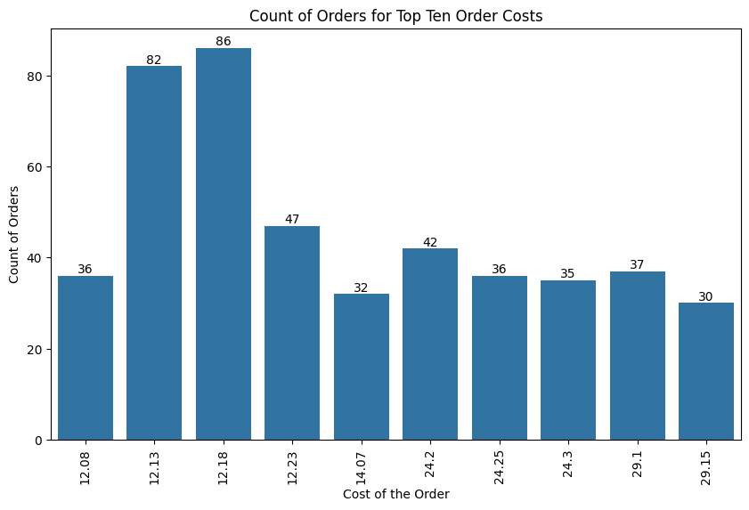

```python
# Histogram
plt.figure(figsize=(10, 6))
sns.histplot(data=df, x='cost_of_the_order',bins=20, kde=True)
plt.title('Distribution of Order Costs')
plt.xlabel('Cost of the Order')
plt.ylabel('Frequency')
plt.show()

#add line
print()

# Boxplot
plt.figure(figsize=(10, 6))
sns.boxplot(data=df, x='cost_of_the_order')
plt.title('Boxplot of Order Costs')
plt.xlabel('Order Cost')
plt.show()

#add line
print()


#count plot
plt.figure(figsize=(10, 6))
ax=sns.countplot(data=df[df['cost_of_the_order'].isin(top_10_costs.index)], x='cost_of_the_order')
plt.title('Count of Orders for Top Ten Order Costs')
plt.xlabel('Cost of the Order')
plt.ylabel('Count of Orders')
plt.xticks(rotation=45)

# Add text labels above each bar
for p in ax.patches:
    ax.annotate(f'{int(p.get_height())}', (p.get_x() + p.get_width() / 2., p.get_height()),
                ha='center', va='center', fontsize=10, color='black', xytext=(0, 5),
                textcoords='offset points')

plt.xticks(rotation=90)  # Rotate x-axis labels for better readability
plt.show()
```

- Cost of the order is right-skewed. This suggests there are some orders with significantly higher costs.
- There are no outliers.
- The most popular cost for an order is 12.18 USD wtih 86 orders.

# Day of the Week

```python
# Group the DataFrame by 'day_of_the_week'
day_counts = df.groupby('day_of_the_week')['day_of_the_week'].count()

print(day_counts)
```

```
day_of_the_week
Weekday     547
Weekend    1351
Name: day_of_the_week, dtype: int64
```

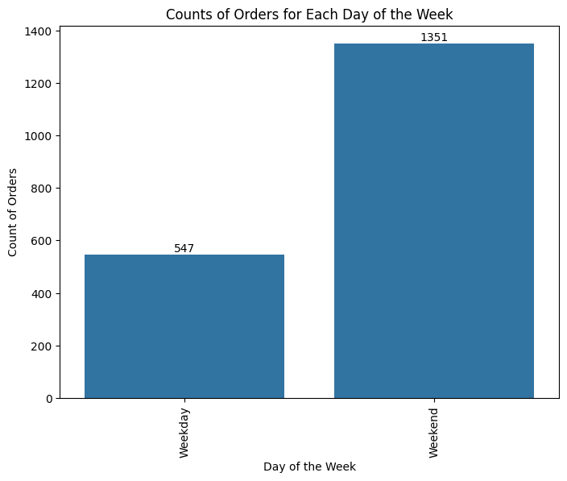

```python
#barplot for day of the week count
plt.figure(figsize=(8, 6))
ax = sns.barplot(x=day_counts.index, y=day_counts.values)
plt.title('Counts of Orders for Each Day of the Week')
plt.xlabel('Day of the Week')
plt.ylabel('Count of Orders')

# Add text labels above each bar
for p in ax.patches:
    ax.annotate(f'{int(p.get_height())}', (p.get_x() + p.get_width() / 2., p.get_height()),
                ha='center', va='center', fontsize=10, color='black', xytext=(0, 5),
                textcoords='offset points')

plt.xticks(rotation=90)  # Rotate x-axis labels for better readability
plt.show()
```

- Most of the orders (about 71%) are placed in the weekend.

# rating

```python
# checking missing values
not_given_rating_count = len(df[df['rating'].str.lower()=='not given']['rating'])

print(f" - There are {not_given_rating_count} missing ('Not given') values in the rating variable")

# Get total number of rows in the DataFrame
total_rows_count = df.shape[0]

# Calculate the percentage of 'Not given' ratings
percent_of_not_given = int(not_given_rating_count * 100 / total_rows_count)

print(f" - About {percent_of_not_given}% of the rating data is missing ('Not given').")

# Checking ratings equal to 5
five_rating_count = len(df[df['rating']=='5']['rating'])
print(f" - There are {five_rating_count} 5-star ratings in the rating variable")
```

```
 - There are 736 missing ('Not given') values in the rating variable
 - About 38% of the rating data is missing ('Not given').
 - There are 588 5-star ratings in the rating variable
```

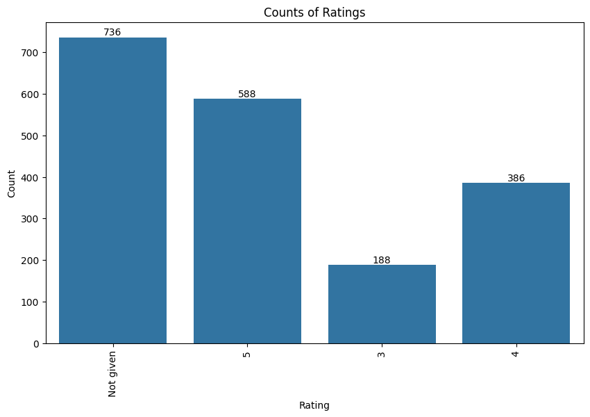

```python
# Create a count plot for the 'rating' column
plt.figure(figsize=(10, 6))
ax = sns.countplot(data=df, x='rating')
plt.title('Counts of Ratings')
plt.xlabel('Rating')
plt.ylabel('Count')

# Add text labels above each bar
for p in ax.patches:
    ax.annotate(f'{int(p.get_height())}', (p.get_x() + p.get_width() / 2., p.get_height()),
                ha='center', va='center', fontsize=10, color='black', xytext=(0, 5),
                textcoords='offset points')

plt.xticks(rotation=90)  # Rotate x-axis labels for better readability
plt.show()
```

- There are 736 missing (Not given) values in the rating variable.
- There are 588 5-star ratings.
- There are 386 4-star ratings.
- There are 188 3-star ratings.
- There are no 1 or 2-ratings.
- There's a positive overall customer sentiment towards the products or services being rated.

# Food Preparation Time

```python
#basic stats
df['food_preparation_time'].describe().T
```

```
count    1898.000000
mean       27.371970
std         4.632481
min        20.000000
25%        23.000000
50%        27.000000
75%        31.000000
max        35.000000
Name: food_preparation_time, dtype: float64
```

- The average preparation time is approximately 27 minutes, suggesting efficiency in food preparation processes.
- Minimal variability, as indicated by the relatively low standard deviation of 4.63 minutes

```python
#print unique food preparation time
print(f" - There are {len(df['food_preparation_time'].unique())} unique food preparing time")
```

```
 - There are 16 unique food preparing time
```

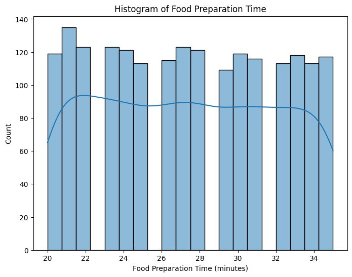

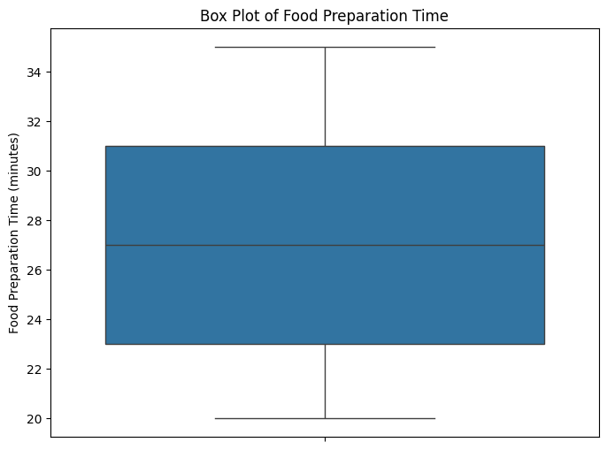

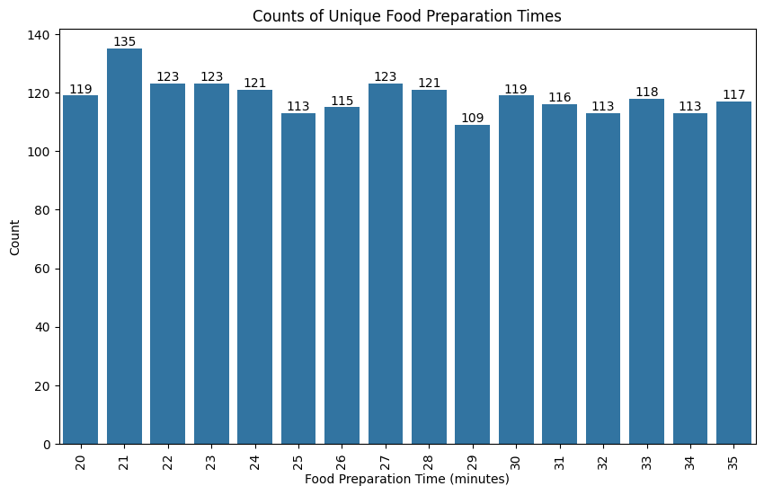

```python
# Histogram for food_preparation_time
plt.figure(figsize=(8, 6))
sns.histplot(data=df, x='food_preparation_time', bins=20, kde=True)
plt.title('Histogram of Food Preparation Time')
plt.xlabel('Food Preparation Time (minutes)')
plt.ylabel('Count')
plt.show()

#add a line
print()

# Box plot for food_preparation_time
plt.figure(figsize=(8, 6))
sns.boxplot(data=df, y='food_preparation_time')
plt.title('Box Plot of Food Preparation Time')
plt.ylabel('Food Preparation Time (minutes)')
plt.show()

#add a line
print()

#unique food preparation times
unique_preparation_times = df['food_preparation_time'].value_counts()
unique_preparation_times=unique_preparation_times.reset_index()

#count plot for the top 10 most common food preparation times
plt.figure(figsize=(10, 6))
ax =sns.barplot(data=unique_preparation_times, x='food_preparation_time', y='count')
plt.title('Counts of Unique Food Preparation Times')
plt.xlabel('Food Preparation Time (minutes)')
plt.ylabel('Count')

# Add text labels above each bar
for p in ax.patches:
    ax.annotate(f'{int(p.get_height())}', (p.get_x() + p.get_width() / 2., p.get_height()),
                ha='center', va='center', fontsize=10, color='black', xytext=(0, 5),
                textcoords='offset points')

plt.xticks(rotation=90)  # Rotate x-axis labels for better readability
plt.show()
```

- There are no outlier record in food_preparation_time
- A relatively consistent distribution, with most orders being prepared within 20 to 35 minutes.
- Most orders have a processing time of 21 minutes.

# Delivery Time

```python
#basic stats
df['delivery_time'].describe().T
```

```
count    1898.000000
mean       24.161749
std         4.972637
min        15.000000
25%        20.000000
50%        25.000000
75%        28.000000
max        33.000000
Name: delivery_time, dtype: float64
```

- Consistent Delivery Times: The data indicates a consistent delivery time experience, with orders typically taking around 24 minutes on average.
- Efficiency and Timeliness: The majority of orders are delivered within a reasonable timeframe, reflecting an efficient and timely delivery service

```python
print(f" - There are {len(df['delivery_time'].unique())} unique delivery time.")
```

```
 - There are 19 unique delivery time.
```

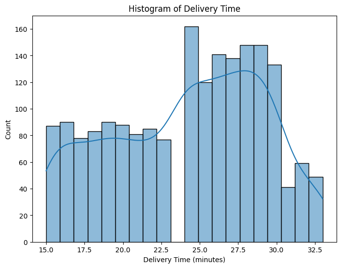

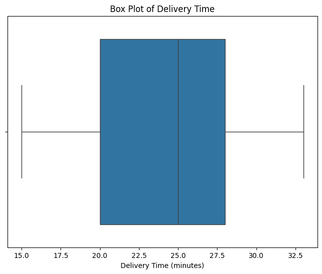

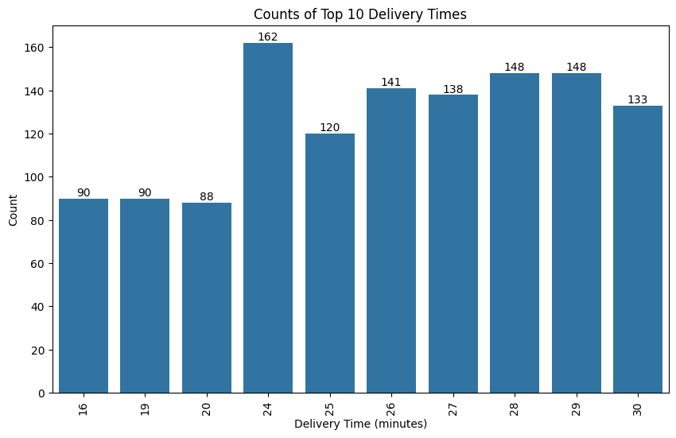

```python
# Histogram for delivery_time
plt.figure(figsize=(8, 6))
sns.histplot(data=df, x='delivery_time', bins=20, kde=True)
plt.title('Histogram of Delivery Time')
plt.xlabel('Delivery Time (minutes)')
plt.ylabel('Count')
plt.show()

# Add a line
print()

# Box plot for delivery_time
plt.figure(figsize=(8, 6))
sns.boxplot(data=df, x='delivery_time')
plt.title('Box Plot of Delivery Time')
plt.xlabel('Delivery Time (minutes)')
plt.show()

# Add a line
print()

# Top 10 most common delivery times
top_10_delivery_times = df['delivery_time'].value_counts().head(10)

# Count plot for the top 10 most common delivery times
plt.figure(figsize=(10, 6))
ax=sns.countplot(data=df[df['delivery_time'].isin(top_10_delivery_times.index)], x='delivery_time')
plt.title('Counts of Top 10 Delivery Times')
plt.xlabel('Delivery Time (minutes)')
plt.ylabel('Count')

# Add text labels above each bar
for p in ax.patches:
    ax.annotate(f'{int(p.get_height())}', (p.get_x() + p.get_width() / 2., p.get_height()),
                ha='center', va='center', fontsize=10, color='black', xytext=(0, 5),
                textcoords='offset points')

plt.xticks(rotation=90)  # Rotate x-axis labels for better readability
plt.show()
```

- Delivery time is skewed to the left
- The most frequent delivery time is 24 minutes with 162 orders.

### **Question 7**: Which are the top 5 restaurants in terms of the number of orders received? [1 mark]

```python
# top 5 restaurants with the most orders
df.groupby('restaurant_name')['restaurant_name'].value_counts().sort_values(ascending=False).head(5)
```

```
restaurant_name
Shake Shack                  219
The Meatball Shop            132
Blue Ribbon Sushi            119
Blue Ribbon Fried Chicken     96
Parm                          68
Name: count, dtype: int64
```

Following are five popular restaurants:

1. Shake Shack with 219 orders
2. The Meatball Shop with 132 orders
3. Blue Ribbon Sushi with 119 orders
4. Blue Ribbon Fried Chicken with 96 orders
5. Parm with 68 orders

#### Observations:

### **Question 8**: Which is the most popular cuisine on weekends? [1 mark]

```python
# Most popular cuisine on weekends
most_popular_weekend_cuisine = df[df['day_of_the_week'].str.lower() == 'weekend']['cuisine_type'].value_counts().head(1)

print(most_popular_weekend_cuisine)
```

```
cuisine_type
American    415
Name: count, dtype: int64
```

- American cuisine is the most popular cuisine type sold on weekends with 415 orders.

#### Observations:

### **Question 9**: What percentage of the orders cost more than 20 dollars? [2 marks]

```python
# get the number of orders with cost more than 20 dollars
num_orders_above_20 = df[df['cost_of_the_order'] > 20].shape[0]

# get the total number of orders
total_orders = df.shape[0]

# Calculate the percentage
percentage_above_20 = (num_orders_above_20 / total_orders) * 100

print(f"The percentage of orders that cost more than 20 dollars is: {percentage_above_20:.2f}%")
```

```
The percentage of orders that cost more than 20 dollars is: 29.24%
```

#### Observations:

### **Question 10**: What is the mean order delivery time? [1 mark]

```python
# mean order delivery time
df['delivery_time'].mean()
```

```
24.161749209694417
```

- The mean order delivery time is 24.16 minutes.

#### Observations:

### **Question 11:** The company has decided to give 20% discount vouchers to the top 3 most frequent customers. Find the IDs of these customers and the number of orders they placed. [1 mark]

```python
# Group by 'customer_id' and count the number of orders for each customer
customer_order_counts = df['customer_id'].value_counts().head(3)

print("Top 3 most frequent customers and the number of orders they placed:")
print(customer_order_counts)
```

```
Top 3 most frequent customers and the number of orders they placed:
customer_id
52832    13
47440    10
83287     9
Name: count, dtype: int64
```

Top 3 most frequent customers and the number of orders they placed:

1. Customer ID 52832 placed 13 orders.
2. Customer ID 47440 placed 10 orders.
3. Customer ID 83287 placed 9 orders.

#### Observations:

### **Question 12**: Perform a multivariate analysis to explore relationships between the important variables in the dataset. (It is a good idea to explore relations between numerical variables as well as relations between numerical and categorical variables) [10 marks]

# Case 1: Exploring relations between numerical variables

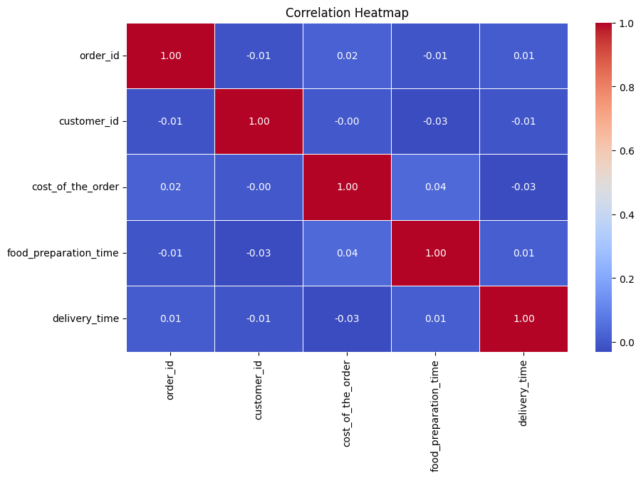

```python
# Extracting only numerical columns for correlation
numerical_df = df.select_dtypes(include=['float64', 'int64'])

# Correlation heatmap for numerical variables
plt.figure(figsize=(10, 6))
sns.heatmap(numerical_df.corr(), annot=True, cmap='coolwarm', fmt='.2f', linewidths=0.5)
plt.title('Correlation Heatmap')
plt.show()
```

**Numeric Data correlation insight**

- All the correlations between the numerical variables are very weak.
- *cost_of_the_order* has a slightly positive but very weak correlation with *food_preparation_time* (0.04)
- There is a slightly negative correlation between *cost_of_the_order* and *delivery_time* (-0.03).

There are no strong linear relationships between the numerical variables in this dataset.

# Working with the cleaned data while using rating:

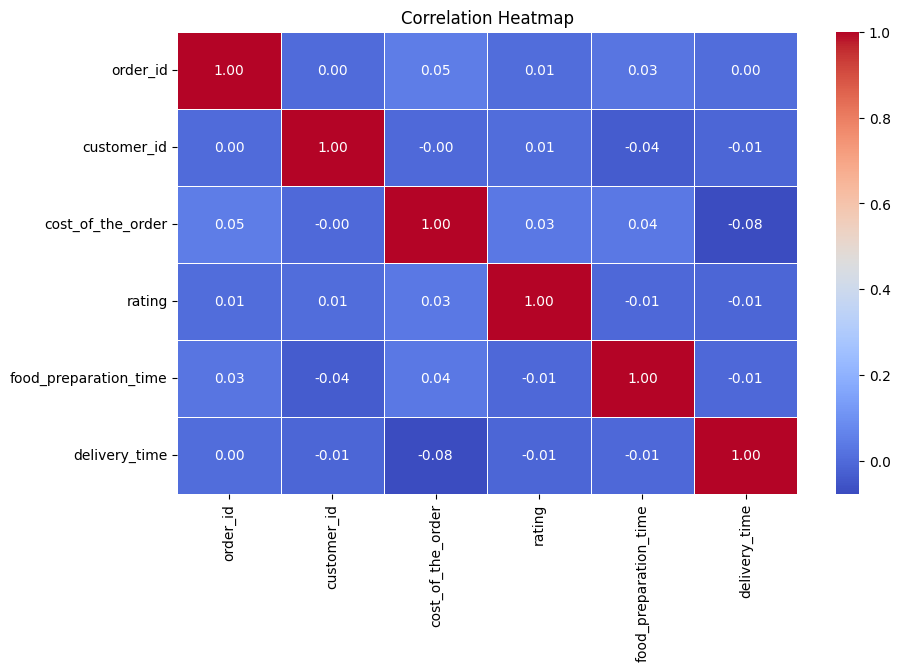

```python
# Explore correlations with other variables using a heatmap
# Convert 'rating' column to numeric
rating_cleaned_df['rating'] = pd.to_numeric(rating_cleaned_df['rating'], errors='coerce')
rating_cleaned_df['rating'] = rating_cleaned_df['rating'].fillna(0).astype(int)

# Filter DataFrame to include only numeric columns
numeric_df = rating_cleaned_df.select_dtypes(include=['float64', 'int64'])

# Explore correlations with other numeric variables using a heatmap
plt.figure(figsize=(10, 6))
sns.heatmap(numeric_df.corr(), annot=True, cmap='coolwarm', fmt='.2f', linewidths=0.5)
plt.title('Correlation Heatmap')
plt.show()
```

- Weak positive correlation: The correlation coefficient between 'cost_of_the_order' and 'rating' is approximately 0.03.

**The most rated cuisine type and restaurant**

```python
df_cleaned = df[df['rating'] != 'Not given'].copy()

# Convert 'rating' column to integers
df_cleaned['rating'] = df_cleaned['rating'].astype(int)
# Find the most rated cuisine type
most_rated_cuisine = df_cleaned.groupby('cuisine_type')['rating'].count().sort_values(ascending=False).head(1)

# Find the most rated restaurant
most_rated_restaurant = df_cleaned.groupby('restaurant_name')['rating'].count().sort_values(ascending=False).head(1)

# Display the results
print("Most rated cuisine type:")
print(most_rated_cuisine)

print("\nMost rated restaurant:")
print(most_rated_restaurant)
```

```
Most rated cuisine type:
cuisine_type
American    368
Name: rating, dtype: int64

Most rated restaurant:
restaurant_name
Shake Shack    133
Name: rating, dtype: int64
```

- The most rated cuisine type is American with 368 ratings.
- The most rated restaurant is Shake Shack with 133 ratings.

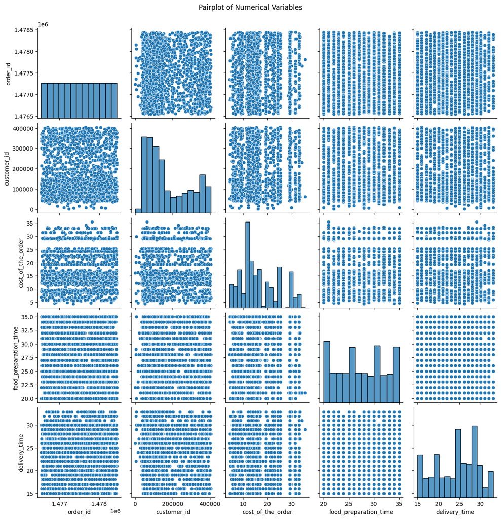

```python
# Pairplot for numerical variables
sns.pairplot(numerical_df)
plt.suptitle('Pairplot of Numerical Variables', y=1.02)
plt.show()
```

- There is no significant positive or negative correlation between numerical variables.

# Case 2: Exploring numerical and categorical variables relationships

We will be focusing on the ones that have significant relationships.

1. delivery_time and cuisine_type
2. delivery_time and day_of_the_week

```python
# Scenario 1: Delivery Time vs. Cuisine Type
# Grouping the data by cuisine type
grouped_by_cuisine = df.groupby('cuisine_type')['delivery_time']

# Summary statistics for delivery time within each cuisine type group
delivery_time_summary = grouped_by_cuisine.describe()

# Calculate median separately
median_delivery_time = grouped_by_cuisine.median()

# Insert median into the summary statistics dataframe
delivery_time_summary.insert(5, 'median', median_delivery_time)

delivery_time_summary = grouped_by_cuisine.describe().transpose()
# Print summary statistics
print(delivery_time_summary)
```

```
cuisine_type    American     Chinese     French     Indian     Italian  \
count         584.000000  215.000000  18.000000  73.000000  298.000000
mean           24.193493   23.855814  25.333333  24.082192   24.567114
std             4.831844    4.966491   3.741657   5.054573    5.179329
min            15.000000   15.000000  17.000000  15.000000   15.000000
25%            20.000000   20.000000  23.250000  20.000000   20.000000
50%            25.000000   24.000000  27.000000  25.000000   26.000000
75%            28.000000   28.000000  28.750000  29.000000   28.750000
max            33.000000   33.000000  29.000000  32.000000   33.000000

cuisine_type    Japanese     Korean  Mediterranean    Mexican  Middle Eastern  \
count         470.000000  13.000000      46.000000  77.000000       49.000000
mean           24.131915  20.923077      23.586957  24.389610       24.081633
std             4.987366   4.030334       5.422489   4.559997        5.663615
min            15.000000  16.000000      15.000000  16.000000       15.000000
25%            20.000000  17.000000      19.000000  21.000000       19.000000
50%            25.000000  20.000000      24.000000  25.000000       25.000000
75%            28.000000  26.000000      28.750000  28.000000       29.000000
max            33.000000  26.000000      33.000000  33.000000       33.000000

cuisine_type   Southern    Spanish       Thai  Vietnamese
count         17.000000  12.000000  19.000000    7.000000
mean          23.823529  23.416667  23.157895   26.142857
std            5.960655   4.813963   4.991806    3.891382
min           15.000000  17.000000  15.000000   19.000000
25%           21.000000  19.750000  19.500000   25.000000
50%           25.000000  23.000000  24.000000   26.000000
75%           28.000000  28.250000  26.500000   28.500000
max           33.000000  30.000000  32.000000   31.000000
```

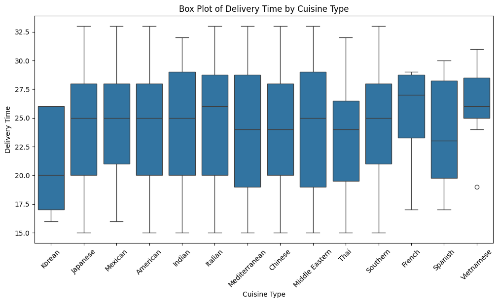

```python
# Scenario 1: Delivery Time vs. Cuisine Type
plt.figure(figsize=(12, 6))
sns.boxplot(x='cuisine_type', y='delivery_time', data=df)
plt.title('Box Plot of Delivery Time by Cuisine Type')
plt.xlabel('Cuisine Type')
plt.ylabel('Delivery Time')
plt.xticks(rotation=45)
plt.show()
```

```
                  count       mean       std   min   25%   50%   75%   max
day_of_the_week
Weekday           547.0  28.340037  2.891428  24.0  26.0  28.0  31.0  33.0
Weekend          1351.0  22.470022  4.628938  15.0  18.5  22.0  27.0  30.0
```

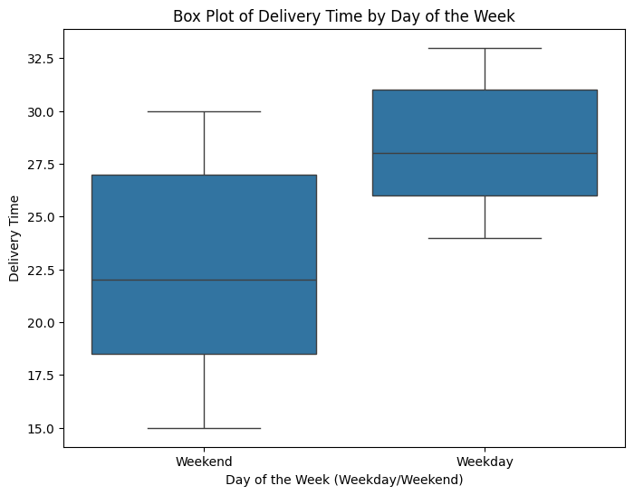

```python
# 2.delivery_time and day_of_the_week
# Grouping the data by weekday/weekend
grouped_by_day_type = df.groupby('day_of_the_week')['delivery_time']

# Summary statistics for delivery time within each weekday/weekend group
delivery_time_summary_day_type = grouped_by_day_type.describe()

# Print summary statistics
print(delivery_time_summary_day_type)
print("\n\n")

# Visualize the distribution of delivery times for weekdays and weekends using box plots
plt.figure(figsize=(8, 6))
sns.boxplot(x='day_of_the_week', y='delivery_time', data=df)
plt.title('Box Plot of Delivery Time by Day of the Week')
plt.xlabel('Day of the Week (Weekday/Weekend)')
plt.ylabel('Delivery Time')
plt.show()
```

- On average, delivery times are shorter on weekends, but there is more variability in delivery times during weekends.

# Case 3: Explorating relationships between categorical variables

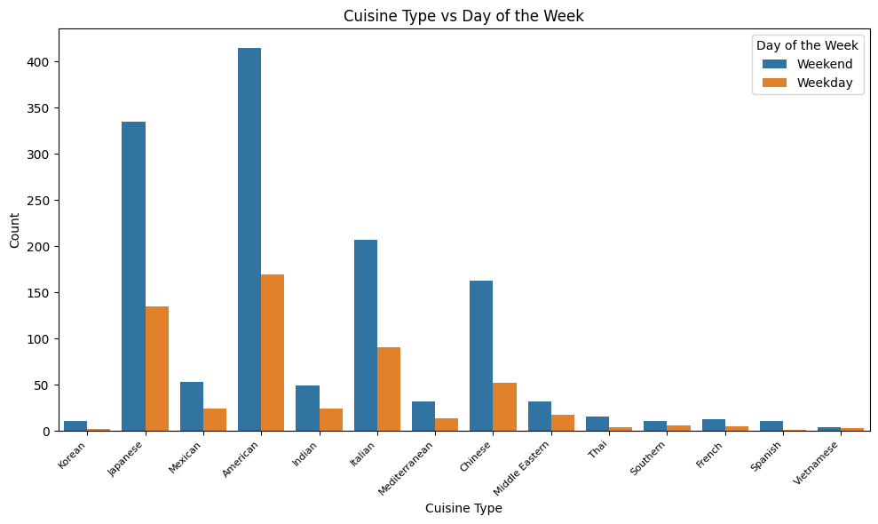

```python
#cuisine_type and day_of_the_week
plt.figure(figsize=(10, 6))
sns.countplot(data=df, x='cuisine_type', hue='day_of_the_week')
plt.xticks(rotation=45, ha='right', fontsize=8)  # Rotate, align, and adjust font size of x-axis labels
plt.title('Cuisine Type vs Day of the Week')
plt.xlabel('Cuisine Type')
plt.ylabel('Count')
plt.legend(title='Day of the Week')
plt.tight_layout()
plt.show()
```

- More cusine types are sold in the weekend than the weekday.

### **Question 13:** The company wants to provide a promotional offer in the advertisement of the restaurants. The condition to get the offer is that the restaurants must have a rating count of more than 50 and the average rating should be greater than 4. Find the restaurants fulfilling the criteria to get the promotional offer. [3 marks]

```python
# Convert 'rating' column to numeric
rating_cleaned_df['rating'] = pd.to_numeric(rating_cleaned_df['rating'], errors='coerce')

# Calculate the mean rating and count of ratings for each restaurant
restaurant_stats = rating_cleaned_df.groupby('restaurant_name')['rating'].agg(['count', 'mean'])

# Filter restaurants based on conditions
eligible_restaurants = restaurant_stats[(restaurant_stats['count'] > 50) & (restaurant_stats['mean'] > 4)]

# Retrieve the restaurant names
promotional_restaurants = eligible_restaurants.index.tolist()

print("Restaurants eligible for promotional offer:")
for restaurant in promotional_restaurants:
    print("-", restaurant)
```

```
Restaurants eligible for promotional offer:
- Blue Ribbon Fried Chicken
- Blue Ribbon Sushi
- Shake Shack
- The Meatball Shop
```

Restaurants eligible for promotional offer:

- Blue Ribbon Fried Chicken
- Blue Ribbon Sushi
- Shake Shack
- The Meatball Shop

#### Observations:

### **Question 14:** The company charges the restaurant 25% on the orders having cost greater than 20 dollars and 15% on the orders having cost greater than 5 dollars. Find the net revenue generated by the company across all orders. [3 marks]

```python
#function to calculate revenue
def calc_revenue(cost):
  if cost>20:
    return cost*0.25
  elif cost > 5:
    return cost*0.15
  else:
    return 0

# Apply the function to calculate revenue for each order
df['revenue'] = df['cost_of_the_order'].apply(calc_revenue)

# Calculate net revenue
net_revenue = df['revenue'].sum()

# Display the net revenue
print("Net revenue generated by the company across all orders: $", net_revenue)
```

```
Net revenue generated by the company across all orders: $ 6166.303
```

- Net revenue generated by the company across all orders: $ 6166.303

#### Observations:

### **Question 15:** The company wants to analyze the total time required to deliver the food. What percentage of orders take more than 60 minutes to get delivered from the time the order is placed? (The food has to be prepared and then delivered.) [2 marks]

```python
# the total time required to deliver the food
prep_total_df=df.copy()
prep_total_df['total_delivery_time'] = prep_total_df['food_preparation_time'] + prep_total_df['delivery_time']

# the number of orders that take more than 60 minutes
num_orders_more_than_60 = prep_total_df[prep_total_df['total_delivery_time'] > 60].shape[0]

# Calculate the percentage of orders that take more than 60 minutes
percentage_more_than_60 = (num_orders_more_than_60 / prep_total_df.shape[0]) * 100

# Display the percentage
print(f"Percentage of orders that take more than 60 minutes to get delivered: {percentage_more_than_60:.2f}%")
```

```
Percentage of orders that take more than 60 minutes to get delivered: 10.54%
```

- Percentage of orders that take more than 60 minutes to get delivered: 10.54%

#### Observations:

### **Question 16:** The company wants to analyze the delivery time of the orders on weekdays and weekends. How does the mean delivery time vary during weekdays and weekends? [2 marks]

```python
# Filter orders for weekdays and weekends
df_weekend = df[df['day_of_the_week'].str.lower() == 'weekend']
df_weekday = df[df['day_of_the_week'].str.lower() == 'weekday']

# Calculate the means
weekend_mean_delivery_time = df_weekend['delivery_time'].mean()
weekday_mean_delivery_time = df_weekday['delivery_time'].mean()

print(f"The mean weekend delivery time is {weekend_mean_delivery_time:.3f} minutes")
print(f"The mean weekday delivery time is {weekday_mean_delivery_time:.3f} minutes")
```

```
The mean weekend delivery time is 22.470 minutes
The mean weekday delivery time is 28.340 minutes
```

- The weekend mean delivery time is shorter than the wekday delivery time.

#### Observations:

### Conclusion and Recommendations

### **Question 17:** What are your conclusions from the analysis? What recommendations would you like to share to help improve the business? (You can use cuisine type and feedback ratings to drive your business recommendations.) [6 marks]

### Conclusions:

### Recommendations:

# Conclusion

**1. Order Costs and Distribution:**

- The average cost of an order is approximately 16.50 USD, with most orders ranging between 12.08 and 22.30 USD.
- The cost distribution is right-skewed, indicating that a few orders have significantly higher costs.

**2. Rating Distribution:**

- There are 736 missing ratings labeled as 'Not given'.
- The majority of ratings are high, with 588 5-star ratings, 386 4-star ratings, and 188 3-star ratings.
- No orders received 1 or 2-star ratings, suggesting general customer satisfaction.

**3. Food Preparation and Delivery Times:**

- The average food preparation time is around 27.37 minutes.
- The average delivery time is approximately 24.16 minutes.
- Delivery times are skewed to the left, with the most frequent delivery time being 24 minutes.

**4. Popular Restaurants and Cuisines:**

- Shake Shack is the most popular restaurant with 219 orders.
- American cuisine is the most popular, particularly on weekends.
- The most rated cuisine type is American with 368 ratings.
- The most rated restaurant name is Shake Shack with 133 ratings.

# Recommendations:

**1. Address Missing Ratings:**

- Implement a follow-up system to encourage customers to provide ratings if they haven't done so initially. This will help in obtaining a complete picture of customer satisfaction.

**2. Improve Order Cost Management:**

- Introduce promotional offers or discounts for mid-range order costs to balance the distribution and attract more orders in this range.

**3. Leverage Popular Restaurants and Cuisines:**

- Promote the most popular restaurants like Shake Shack and cuisine types like American through targeted marketing campaigns.

**4. Increase Customer Satisfaction:**

- Offer incentives for high ratings, such as discount vouchers for future orders, to motivate restaurants to maintain high service standards.

**5. Weekend Promotions:**

- Since American cuisine is highly popular on weekends, consider running weekend-specific promotions for American cuisine to boost sales further.